# Forecasting: Project 2

##### b. ETS(A,A,N)

This Additive error model has Additive trend and no seasonal component. **Note - This is also the Holt’s Local Trend Model: ETS(A,A,N).** In this model, at each point, the data path is approximated by a tangential line in the deterministic case. We can fit 3 different models by considering damping and drift aspects,

**x. General ETS(A,A,N) -**

```r
Add.SS.AAN = ets(solar, model="AAN")
summary(Add.SS.AAN)
```

```
## ETS(A,Ad,N)
##
## Call:
##  ets(y = solar, model = "AAN")
##
##   Smoothing parameters:
##     alpha = 0.9279
##     beta  = 0.9279
##     phi   = 0.8
##
##   Initial states:
##     l = 13.7196
##     b = 2.5786
##
##   sigma:  3.4657
##
##      AIC     AICc      BIC
## 5932.524 5932.653 5959.478
##
## Training set error measures:
##                        ME     RMSE      MAE      MPE     MAPE      MASE
## Training set -0.008312543 3.452593 2.638571 3.790894 19.25631 0.4334691
##                    ACF1
## Training set 0.07272876
```

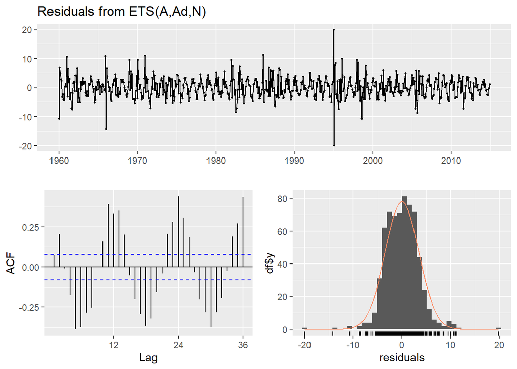

```
##
##  Ljung-Box test
##
## data:  Residuals from ETS(A,Ad,N)
## Q* = 1134, df = 24, p-value < 2.2e-16
##
## Model df: 0.   Total lags used: 24
```

```r
checkresiduals(Add.SS.AAN)
```

**Model summary:**

- MASE measure improves to 0.4334691 (vs 0.6368203 of ETS(A,N,N)).
- Serial autocorrelations are highly significant

**y. ETS(A,A,N) with drift -**

A local **trend** model allows the growth rate to change stochastically over time. If $\beta$=0, the growth rate is constant and equal to a value that will be denoted by b. This model is hence the **local level model with drift** and is also known as simple exponential smoothing with drift. We use ets() function with beta=0 to fit this model. We set the argument beta to a value very close to zero.

```r
Add.SS.AAN.drift = ets(solar, model="AAN", beta = 1E-4)
summary(Add.SS.AAN.drift)
```

```
## ETS(A,A,N)
##
## Call:
##  ets(y = solar, model = "AAN", beta = 1e-04)
##
##   Smoothing parameters:
##     alpha = 0.9999
##     beta  = 1e-04
##
##   Initial states:
##     l = 11.356
##     b = -0.0206
##
##   sigma:  4.5898
##
##      AIC     AICc      BIC
## 6300.338 6300.399 6318.307
##
## Training set error measures:
##                       ME     RMSE      MAE       MPE     MAPE      MASE
## Training set 0.009889528 4.575899 3.887095 -5.243348 27.46947 0.6385788
##                   ACF1
## Training set 0.6652999
```

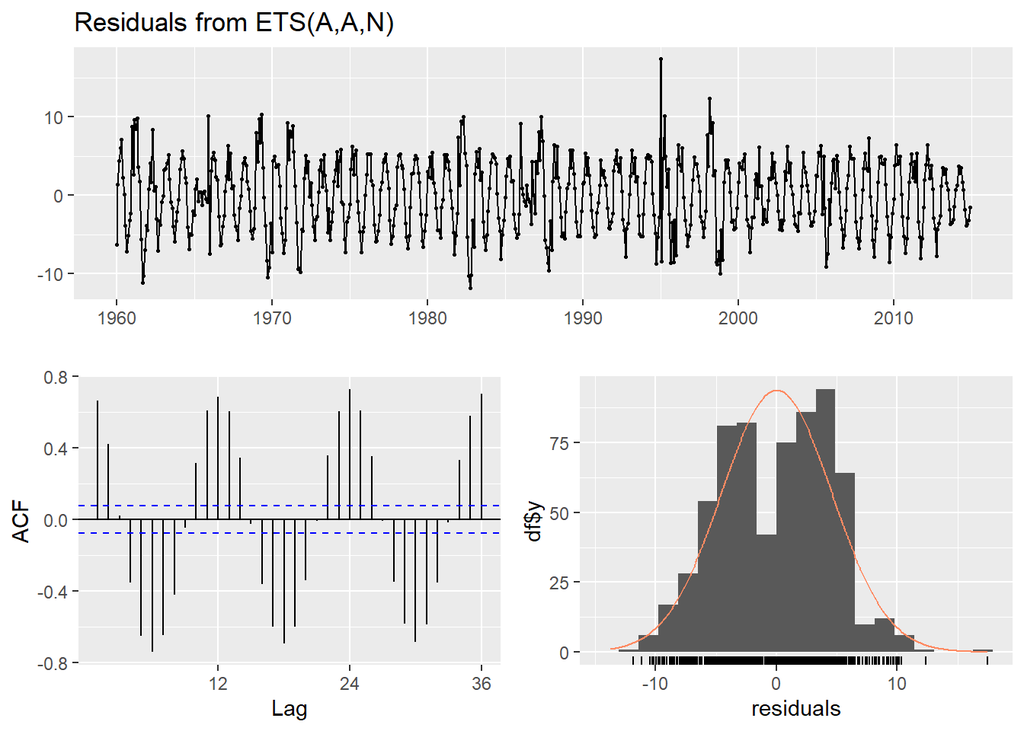

```
##
##  Ljung-Box test
##
## data:  Residuals from ETS(A,A,N)
## Q* = 4200.2, df = 24, p-value < 2.2e-16
##
## Model df: 0.   Total lags used: 24
```

```r
checkresiduals(Add.SS.AAN.drift)
```

**Model summary:**

- MASE measure degrades to 0.6385788 (vs 0.4334691 of ETS(A,A,N)). (Drift worsens the model)
- Serial autocorrelations are highly significant

**z. ETS(A,A,N) with damping -**

```r
Add.SS.AAN.damped = ets(solar, model="AAN")
summary(Add.SS.AAN.damped)
```

```
## ETS(A,Ad,N)
##
## Call:
##  ets(y = solar, model = "AAN")
##
##   Smoothing parameters:
##     alpha = 0.9279
##     beta  = 0.9279
##     phi   = 0.8
##
##   Initial states:
##     l = 13.7196
##     b = 2.5786
##
##   sigma:  3.4657
##
##      AIC     AICc      BIC
## 5932.524 5932.653 5959.478
##
## Training set error measures:
##                        ME     RMSE      MAE      MPE     MAPE      MASE
## Training set -0.008312543 3.452593 2.638571 3.790894 19.25631 0.4334691
##                    ACF1
## Training set 0.07272876
```

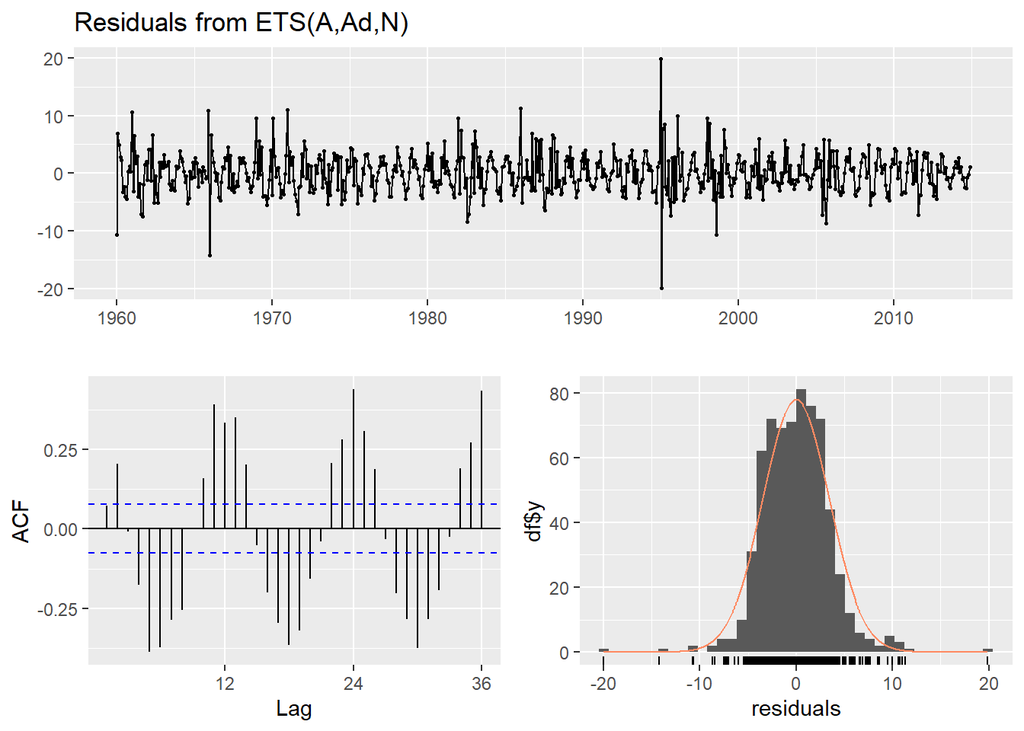

```
##
##  Ljung-Box test
##
## data:  Residuals from ETS(A,Ad,N)
## Q* = 1134, df = 24, p-value < 2.2e-16
##
## Model df: 0.   Total lags used: 24
```

```r
checkresiduals(Add.SS.AAN.damped)
```

**Model summary:**

- MASE measure degrades to 0.4334691 (vs 0.4334691 of general ETS(A,A,N)). (Damping makes no difference)
- Serial autocorrelations are highly significant

##### c. ETS(A,N,A)

This Additive error model has additive seasonal and no trend component.

```r
Add.SS.ANA = ets(solar, model="ANA")
summary(Add.SS.ANA)
```

```
## ETS(A,N,A)
##
## Call:
##  ets(y = solar, model = "ANA")
##
##   Smoothing parameters:
##     alpha = 0.9997
##     gamma = 3e-04
##
##   Initial states:
##     l = 22.6142
##     s = -10.2887 -8.5269 -4.0534 1.7184 7.355 10.8208
##            10.4774 7.7101 2.4749 -1.7156 -6.7936 -9.1783
##
##   sigma:  2.3884
##
##      AIC     AICc      BIC
## 5449.974 5450.719 5517.358
##
## Training set error measures:
##                      ME     RMSE     MAE       MPE     MAPE     MASE      ACF1
## Training set -0.0108645 2.362974 1.55041 -2.640142 12.95336 0.254704 0.1825724
```

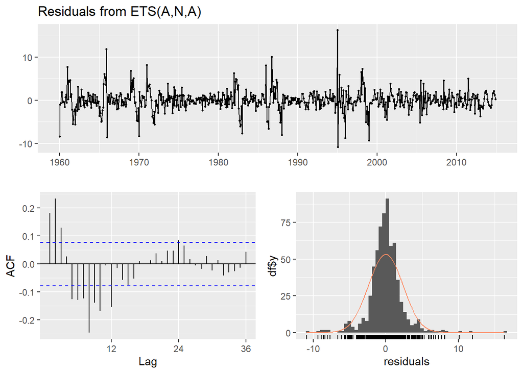

```
##
##  Ljung-Box test
##
## data:  Residuals from ETS(A,N,A)
## Q* = 207.44, df = 24, p-value < 2.2e-16
##
## Model df: 0.   Total lags used: 24
```

```r
checkresiduals(Add.SS.ANA)
```

##### d. ETS(A,A,A)

This Additive error model has Additive trend and Additive seasonal component. **Note - This is also the Local Additive Seasonal Model: ETS(A,A,A).**

```r
Add.SS.AAA = ets(solar, model="AAA")
summary(Add.SS.AAA)
```

```
## ETS(A,Ad,A)
##
## Call:
##  ets(y = solar, model = "AAA")
##
##   Smoothing parameters:
##     alpha = 0.9999
##     beta  = 1e-04
##     gamma = 1e-04
##     phi   = 0.9388
##
##   Initial states:
##     l = 11.154
##     b = 0.7632
##     s = -10.4919 -8.137 -3.348 2.5794 8.08 11.1219
##            9.9586 6.9916 1.9573 -1.8565 -7.1607 -9.6946
##
##   sigma:  2.3446
##
##      AIC     AICc      BIC
## 5428.422 5429.489 5509.282
##
## Training set error measures:
##                       ME     RMSE      MAE       MPE     MAPE      MASE
## Training set -0.01091357 2.314163 1.498521 -1.468083 12.44796 0.2461797
##                   ACF1
## Training set 0.1700724
```

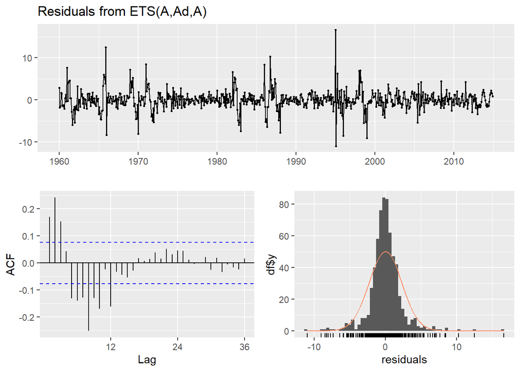

```
##
##  Ljung-Box test
##
## data:  Residuals from ETS(A,Ad,A)
## Q* = 210.76, df = 24, p-value < 2.2e-16
##
## Model df: 0.   Total lags used: 24
```

```r
checkresiduals(Add.SS.AAA)
```

**Model summary:**

- MASE measure imrpoves to 0.2461797 (vs 0.4334691 of general ETS(A,A,N)).
- Serial autocorrelations are highly significant

#### 2. Multiplicative error models: ETS(M,-,-)

Lets not consider drift and damping for each model to maintain simplicity of reporting (The best model will be chosen as per auto-fit anyways).

##### a. ETS(M,N,N)

This Multiplicative error model has no trend or seasonal component. **Note - This is also the Holt-Winters’ Local Level Model: ETS(M,N,N)**

```r
Mul.SS.MNN = ets(solar, model="MNN")
summary(Mul.SS.MNN)
```

```
## ETS(M,N,N)
##
## Call:
##  ets(y = solar, model = "MNN")
##
##   Smoothing parameters:
##     alpha = 0.9999
##
##   Initial states:
##     l = 4.4856
##
##   sigma:  0.3868
##
##      AIC     AICc      BIC
## 6619.776 6619.812 6633.253
##
## Training set error measures:
##                       ME     RMSE      MAE       MPE     MAPE      MASE
## Training set 0.001004352 4.569136 3.877241 -5.195978 27.31733 0.6369599
##                   ACF1
## Training set 0.6678785
```

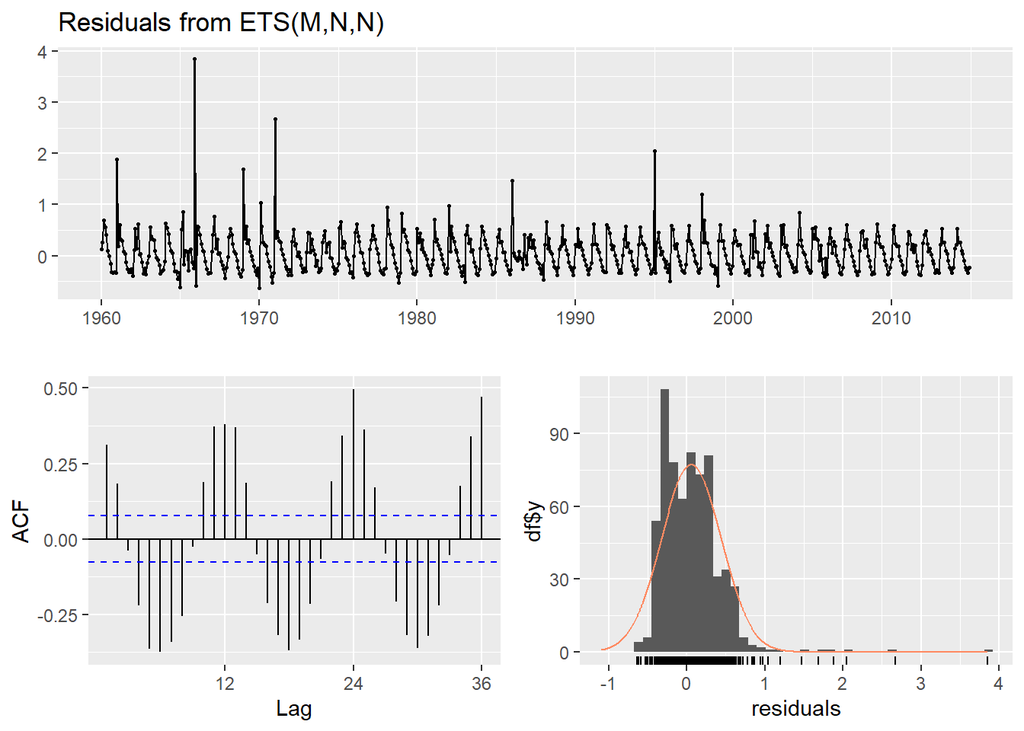

```
##
##  Ljung-Box test
##
## data:  Residuals from ETS(M,N,N)
## Q* = 1334.8, df = 24, p-value < 2.2e-16
##
## Model df: 0.   Total lags used: 24
```

```r
checkresiduals(Mul.SS.MNN)
```

**Model summary:**

- MASE measure degrades to 0.6369599 (vs 0.2035619 Holt-Winters model without error component).
- Serial autocorrelations are highly significant

**Comment -**

Note - MNN model is bad compared to ANN model (MASE - 0.6368203 vs MASE - 0.636959). This is because, our time series is homoscedastic (equal variance of error terms) as seen from its time series plot. And we know for a homoscedastic series, a model with Additive error terms fit the series better than multiplicative error terms.

##### b. ETS(M,A,N)

```r
Mul.SS.MAN = ets(solar, model="MAN")
summary(Mul.SS.MAN)
```

```
## ETS(M,A,N)
##
## Call:
##  ets(y = solar, model = "MAN")
##
##   Smoothing parameters:
##     alpha = 0.9999
##     beta  = 0.0018
##
##   Initial states:
##     l = 7.8559
##     b = 2.4488
##
##   sigma:  0.3004
##
##      AIC     AICc      BIC
## 6433.364 6433.456 6455.825
##
## Training set error measures:
##                     ME     RMSE      MAE       MPE     MAPE      MASE      ACF1
## Training set -1.466339 4.822041 3.964894 -17.35094 30.69019 0.6513597 0.6697971
```

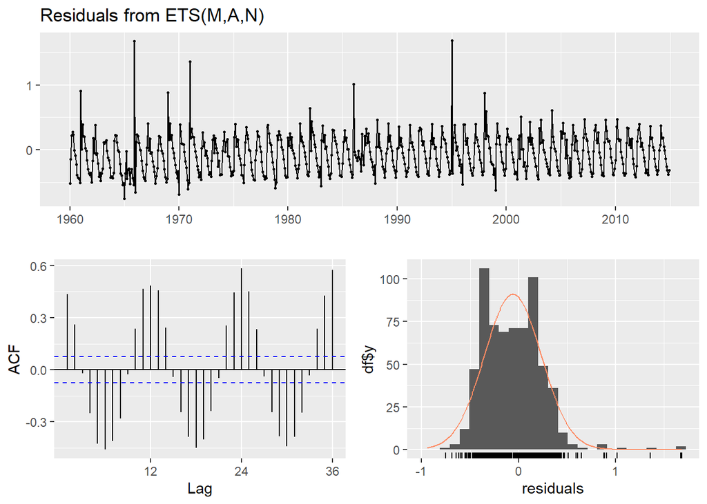

```
##
##  Ljung-Box test
##
## data:  Residuals from ETS(M,A,N)
## Q* = 2007.1, df = 24, p-value < 2.2e-16
##
## Model df: 0.   Total lags used: 24
```

```r
checkresiduals(Mul.SS.MAN)
```

**Model summary:**

- MASE measure degrades to 0.6513597
- Serial autocorrelations are highly significant

##### c. ETS(M,A,A)

```r
Mul.SS.MAA = ets(solar, model="MAA")
summary(Mul.SS.MAA)
```

```
## ETS(M,Ad,A)
##
## Call:
##  ets(y = solar, model = "MAA")
##
##   Smoothing parameters:
##     alpha = 0.5273
##     beta  = 0.0035
##     gamma = 0.0104
##     phi   = 0.8
##
##   Initial states:
##     l = 11.5982
##     b = 2.6304
##     s = -10.4131 -6.5688 -2.8947 0.153 7.6029 8.4081
##            8.1855 8.4954 2.4863 -2.2582 -6.2468 -6.9497
##
##   sigma:  0.3329
##
##      AIC     AICc      BIC
## 6469.079 6470.146 6549.940
##
## Training set error measures:
##                       ME     RMSE      MAE       MPE     MAPE      MASE
## Training set -0.02086702 3.282879 2.311939 -5.186754 18.98277 0.3798095
##                  ACF1
## Training set 0.551665
```

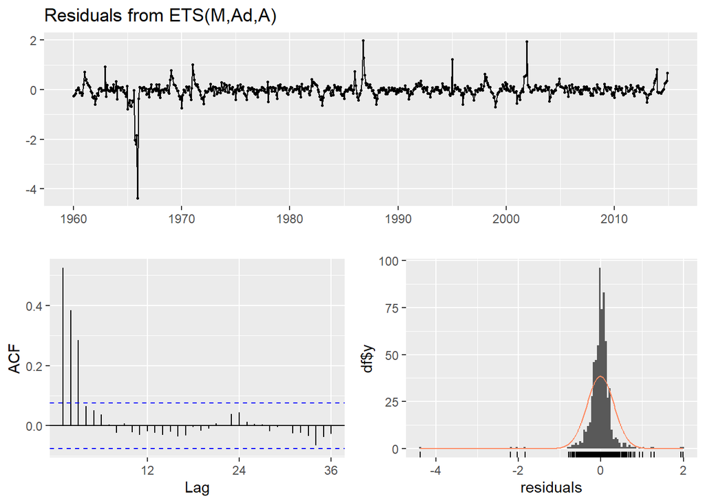

```
##
##  Ljung-Box test
##
## data:  Residuals from ETS(M,Ad,A)
## Q* = 346.85, df = 24, p-value < 2.2e-16
##
## Model df: 0.   Total lags used: 24
```

```r
checkresiduals(Mul.SS.MAA)
```

**Model summary:**

- MASE measure improves to 0.3798095
- Serial autocorrelations are highly significant

##### d. ETS(M,A,M)

Note - This is also the **Non-linear seasonal model**, namely, Multiplicative Seasonal and Error Model: ETS(M,A,M). When the pattern of seasonality changes through time, linear seasonal structure cant be used. In that case, we use nonlinear seasonal models. It is hard to tell if our solar radiation series’s seasonality pattern changes through time or not. So, lets consider the nonlinear multiplicative seasonal component (MAM) model,

```r
Mul.SS.MAM = ets(solar, model="MAM")
summary(Mul.SS.MAM)
```

```
## ETS(M,Ad,M)
##
## Call:
##  ets(y = solar, model = "MAM")
##
##   Smoothing parameters:
##     alpha = 0.7922
##     beta  = 6e-04
##     gamma = 0.0707
##     phi   = 0.98
##
##   Initial states:
##     l = 9.3693
##     b = 1.2404
##     s = 0.6953 0.3066 0.5802 0.9879 1.3594 1.5469
##            1.4723 1.4055 1.227 0.9573 0.6959 0.7656
##
##   sigma:  0.2274
##
##      AIC     AICc      BIC
## 5953.502 5954.569 6034.363
##
## Training set error measures:
##                     ME    RMSE      MAE       MPE     MAPE      MASE      ACF1
## Training set 0.1750605 3.02791 1.961614 -5.497209 17.21119 0.3222574 0.2565219
```

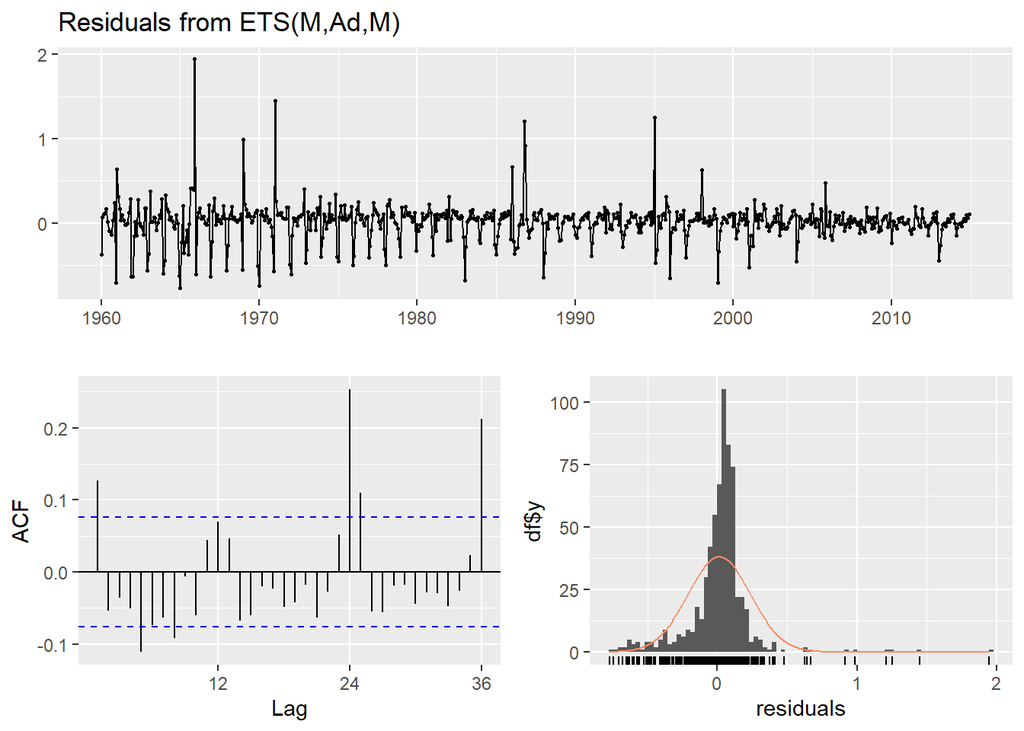

```
##
##  Ljung-Box test
##
## data:  Residuals from ETS(M,Ad,M)
## Q* = 102.28, df = 24, p-value = 1.222e-11
##
## Model df: 0.   Total lags used: 24
```

```r
checkresiduals(Mul.SS.MAM)
```

**Model summary:**

- MASE measure improves to 0.3222574
- Serial autocorrelations are highly significant

##### e. ETS(M,M,N)

We know our series is seasonal, so not having seasonal component as none (MMN) should be a bad fit. Lets check anyways,

```r
Mul.SS.MMN = ets(solar, model="MMN")
summary(Mul.SS.MMN)
```

```
## ETS(M,M,N)
##
## Call:
##  ets(y = solar, model = "MMN")
##
##   Smoothing parameters:
##     alpha = 0.9999
##     beta  = 0.0063
##
##   Initial states:
##     l = 9.1784
##     b = 1.1871
##
##   sigma:  0.3511
##
##      AIC     AICc      BIC
## 6609.163 6609.255 6631.624
##
## Training set error measures:
##                     ME     RMSE      MAE      MPE     MAPE     MASE      ACF1
## Training set -1.644301 5.221518 4.235504 -14.9362 30.65972 0.695816 0.6833568
```

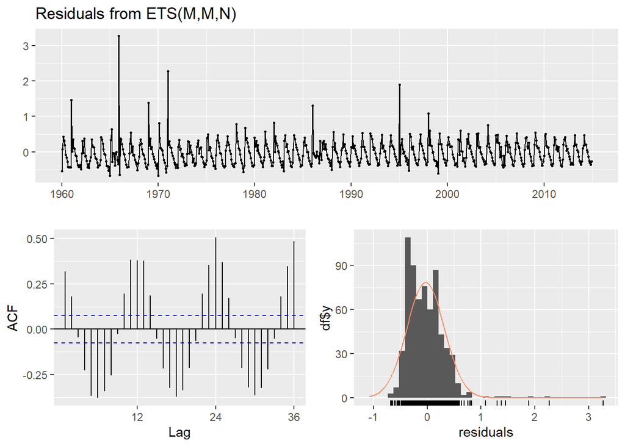

```
##
##  Ljung-Box test
##
## data:  Residuals from ETS(M,M,N)
## Q* = 1371.3, df = 24, p-value < 2.2e-16
##
## Model df: 0.   Total lags used: 24
```

```r
checkresiduals(Mul.SS.MMN)
```

**Model summary:**

- MASE measure degrades to 0.695816
- Serial autocorrelations are highly significant

#### Most appropriate State-Space model based on MASE (Model Selection)

Lets summarise all the State-Space models considered with their corresponding forecast accuracy measure, MASE,

- Additive error models: ETS(A,-,-)
  1. ETS(A,N,N) - Holt’s Local Level Model | 0.6368203
  2. ETS(A,A,N) - Holt’s Local Trend Model
     24. ETS(A,A,N) | 0.4334691
     25. ETS(A,A,N) with drift | 0.6385788
     26. ETS(A,A,N) with damping | 0.4334691
  3. ETS(A,N,A) | 0.254704
  4. ETS(A,A,A) - Holt’s Local Additive Seasonal Model | 0.2461797

Best State-Space model with additive error term is ETS(A,A,A) with MASE measure of 0.2461797.

- Multiplicative error models: ETS(M,-,-)
  1. ETS(M,N,N) - Holt-Winters’ Local Level Model | 0.6369599
  2. ETS(M,A,N) - Holt-Winters’ Local Trend Model | 0.6513597
  3. ETS(M,A,A) - Holt-Winters’ Local Additive Seasonal Model | 0.3798095
  4. ETS(M,A,M) | 0.3222574
  5. ETS(M,M,N) | 0.695816

Best State-Space model with Multiplicative error term is ETS(M,A,M) with MASE measure of 0.3222574.

It seems in general models with Additive error components have better forecasting accuracy measure than their multiplicative error counterpart. It is important to note that, there are many other possible models which we have missed out. To avoid the hassle, we can autofit the best State-Space model using the below code,

```r
autofit.SS = ets(solar)
summary(autofit.SS)
```

```
## ETS(A,Ad,A)
##
## Call:
##  ets(y = solar)
##
##   Smoothing parameters:
##     alpha = 0.9999
##     beta  = 1e-04
##     gamma = 1e-04
##     phi   = 0.9388
##
##   Initial states:
##     l = 11.154
##     b = 0.7632
##     s = -10.4919 -8.137 -3.348 2.5794 8.08 11.1219
##            9.9586 6.9916 1.9573 -1.8565 -7.1607 -9.6946
##
##   sigma:  2.3446
##
##      AIC     AICc      BIC
## 5428.422 5429.489 5509.282
##
## Training set error measures:
##                       ME     RMSE      MAE       MPE     MAPE      MASE
## Training set -0.01091357 2.314163 1.498521 -1.468083 12.44796 0.2461797
##                   ACF1
## Training set 0.1700724
```

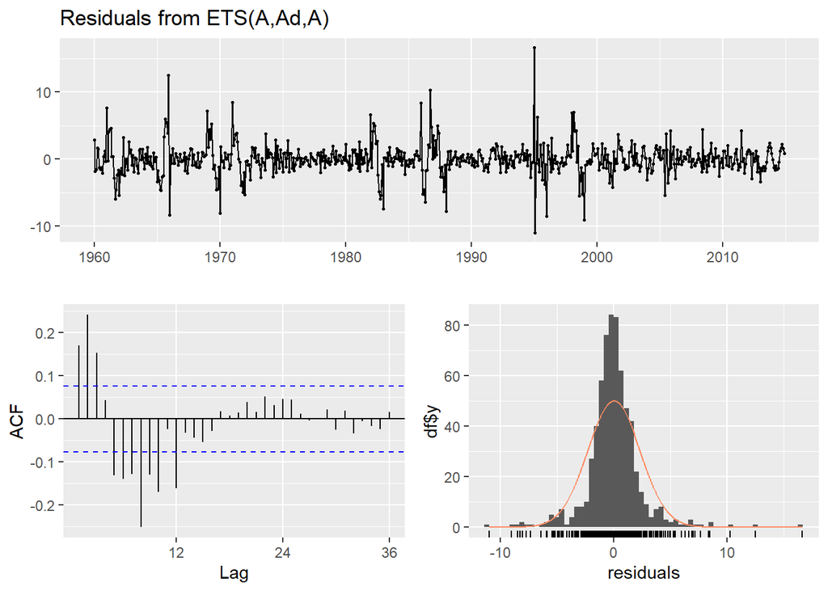

```
##
##  Ljung-Box test
##
## data:  Residuals from ETS(A,Ad,A)
## Q* = 210.76, df = 24, p-value < 2.2e-16
##
## Model df: 0.   Total lags used: 24
```

```r
checkresiduals(autofit.SS) # Autofit finds the ETS(A,Ad,A).
```

The auto fitted model is the **ETS(A,Ad,A)** model having the least MASE value of 0.2461797 of all possible State space models.

#### Conclusion of State-Space method

The best State-space model which gives the most accurate forecasting based on the MASE measure is **ETS(A,Ad,A)** having lowest MASE measure of 0.2461797 of all possible State space models.

### Overall Most Appropriate Regression model (Model Selection)

Based on the 4 Time series regression methods considered, the best model as per MASE measure for each method is summarized below,

- A. Best Distributed lag models is - Autoregressive Distributed Lag model *ARDL(9,12)* with MASE measure of *0.3927514*
- B. Best Dynamic linear models is - None (No intervention points were present)
- C. Best Exponential smoothing model is - **Holt-Winters’ multiplicative Damped model** with MASE measure of **0.2035619**
- D. Best State-Space model is - *ETS(A,Ad,A)* with MASE measure of *0.2461797*

### Best Time Series regression model for Forecasting

Best Time Series regression model is - **Holt-Winters’ multiplicative Damped model ($Mul.hw.damped$)** with MASE measure of **0.2035619**.

## Detailed Graphical and statistical tests of assumptions for $Mul.hw.damped$ model (Residual Analysis)

Residual analysis to test model assumptions.

Lets perform a detailed *Residual Analysis* to check if any model assumptions have been violated.

The estimator error (or residual) is defined by:

$\hat{\epsilon_i}$ = $Y_i$ - $\hat{Y_i}$ (i.e. observed value less - trend value)

The following problems are to be checked,

1. linearity in distribution of error terms
2. The mean value of residuals is zero
3. Serial autocorrelation
4. Normality of distribution of error terms

Lets first apply diagnostic check using checkresiduals() function,

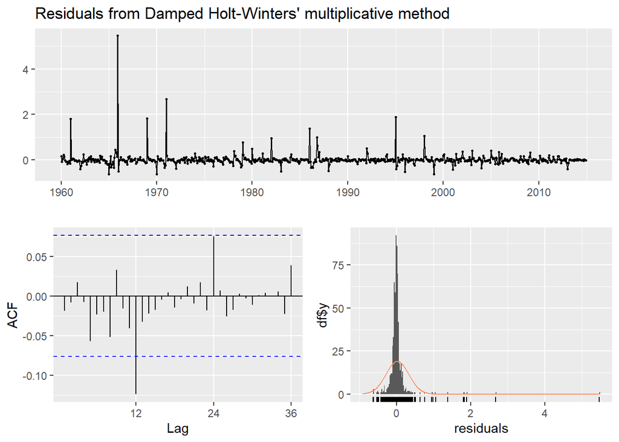

```
##
##  Ljung-Box test
##
## data:  Residuals from Damped Holt-Winters' multiplicative method
## Q* = 23.57, df = 24, p-value = 0.4864
##
## Model df: 0.   Total lags used: 24
```

```r
checkresiduals(Mul.hw.damped)
```

1. From the Residuals plot, linearity is not violated as the residuals are randomly distributed across the mean. Thus, **linearity in distribution of error terms is not violated**
2. To test mean value of residuals is zero or not, lets calculate mean value of residuals as,

```r
mean(Mul.hw.damped$model$residuals)
```

```
## [1] 0.0190173
```

As mean value of residuals is close to 0, **zero mean residuals is not violated**.

3. In the checkresiduals output, the Ljung-Box test output is displayed. According to this test, the hypothesis are,

Which has,  
$H_0$ : series of residuals exhibit no serial autocorrelation of any order up to p  
$H_a$ : series of residuals exhibit serial autocorrelation of any order up to p

From the Ljung-Box test output, since p (0.4864) > 0.05, we do not reject the null hypothesis of no serial autocorrelation.

4. From the histogram shown by checkresiduals(), residuals seem to follow normality. Lets test this statistically,

$H_0$ : Time series is Normally distributed  
$H_a$ : Time series is not normal

```r
shapiro.test(Mul.hw.damped$model$residuals)
```

```
##
##  Shapiro-Wilk normality test
##
## data:  Mul.hw.damped$model$residuals
## W = 0.3802, p-value < 2.2e-16
```

From the Shapiro-Wilk test, since p<0.05 significance level, we reject the null hypothesis that states the data is normal. Thus, residuals of Mul.hw.damped are **Not normally** distributed.

**Summarizing residual analysis on $full$ model:**

Assumption 1: The error terms are randomly distributed and thus show linearity: *Not violated*  
Assumption 2: The mean value of E is zero (zero mean residuals): *Not violated*  
Assumption 4: The error terms are independently distributed, i.e. they are not autocorrelated: *Not violated*  
Assumption 5: The errors are normally distributed. **Violated**

Although normality of residuals assumption is violated, ‘There is no normality assumption in fitting an exponential smoothing model’ (Rob Hyndman 2013). Having no residual assumptions’ violations, the Holt-Winters’ multiplicative Damped model is good for accurate forecasting. Lets forecast for the next 2 years,

## Forecasting

Using the model with best MASE measure, Holt-Winters’ multiplicative Damped model (Mul.hw.damped), lets estimate and plot 2 years (2015 Jan - 2016 Dec) ahead forecasts. The following code chunk displays the fitted model, observed series and forecasts for 2 year time points ahead.

*Note, Since we are forecasting using Holt-Winters’ model which does not incorporate regressor variables, we do not need the regressor (Precipitation) variable’s measures (Unlike Distributed Lag models)*

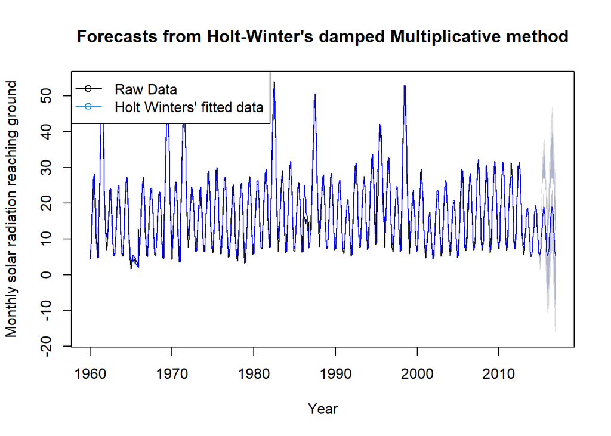

```r
Mul.hw.damped <- hw(solar,seasonal="multiplicative", damped = TRUE, h=2*frequency(solar)) # Revisit the fitted model

plot(Add.hw.damped, ylab="Monthly solar radiation reaching ground", main = "Forecasts from Holt-Winter's damped Multiplicative method", plot.conf=FALSE, type="l", fcol="white", xlab="Year")
lines(fitted(Mul.hw.damped), col="blue", lty=1)
lines(Mul.hw.damped$mean, type="l", col="blue")
legend("topleft",lty=1, pch=1, col=c(1,4),
       c("Raw Data", "Holt Winters' fitted data"))
```

In the plot above, Blue lines after 2014 shows the forecasted 2 year Solar Radiation data. The gray region around it shows the 95% and 80% prediction intervals of the forecasts.

The point forecast values are,

```r
Mul.hw.damped$mean
```

```
##            Jan       Feb       Mar       Apr       May       Jun       Jul
## 2015  5.611616  7.060438 10.515176 12.993446 16.284381 18.261020 19.031597
## 2016  5.616270  7.066360 10.524088 13.004566 16.298445 18.276925 19.048304
##            Aug       Sep       Oct       Nov       Dec
## 2015 17.105654 13.764743  9.774733  6.581938  5.163049
## 2016 17.120781 13.777000  9.783493  6.587872  5.167730
```

# Task 2: Analyzing the Relationship Between Melbourne Property Price Index and Victoria Population Change: Is It Spurious?

## Objective

Our aim for the given dataset is to analyse whether the correlation between the quarterly Property Price Index (PPI) in Melbourne and quarterly population change over the previous quarter in Victoria is spurious or not.

### Read Data

```r
data <- read.csv("C:/Users/admin/Downloads/data2.csv")
data.ts = ts(data, start=c(2003,3),frequency = 4)

head(data.ts)
```

```
##         Quarter price change
## 2003 Q3      41  60.7  14017
## 2003 Q4       1  62.1  12350
## 2004 Q1      28  60.8  17894
## 2004 Q2      15  60.9   9079
## 2004 Q3      42  60.9  16210
## 2004 Q4       2  62.4  13788
```

## Analysing Spurious Correlation

### Identifying Response and Covariate time series

The response, $Y$ = {$Y_t$} is the Price Index (PPI) and the co variate time series, $X$ = {$X_t$} is Population Change that we hope will explain $Y$.

- **Response** time series = Y = Quarterly Property Price Index (PPI) in Melbourne
- **Co-variate** time series = X = Quarterly Population Change over previous quarter in Victoria

**Read Response and Covariate TS -**

```r
data_PPI = data.ts[,2]
head(data_PPI) #Response TS
```

```
##      Qtr1 Qtr2 Qtr3 Qtr4
## 2003           60.7 62.1
## 2004 60.8 60.9 60.9 62.4
```

```r
data_pchange = data.ts[,3]
head(data_pchange) #Covariate TS
```

```
##       Qtr1  Qtr2  Qtr3  Qtr4
## 2003             14017 12350
## 2004 17894  9079 16210 13788
```

```r
data.joint=ts.intersect(data_PPI,data_pchange) # Response and Covariate TS together
head(data.joint)
```

```
##         data_PPI data_pchange
## 2003 Q3     60.7        14017
## 2003 Q4     62.1        12350
## 2004 Q1     60.8        17894
## 2004 Q2     60.9         9079
## 2004 Q3     60.9        16210
## 2004 Q4     62.4        13788
```

### The sample cross-correlation function (sample CCF)

The sample cross-correlation function (sample CCF) defined by,

$r_k(X,Y) = \frac{\sum (X_t - \overline{X})(Y_t - \overline{Y})}{\sqrt{\sum (X_t - \overline{X})^2}\sqrt{\sum (Y_t - \overline{Y})^2}}$

Sample cross-correlations that are larger than 1.96/n in magnitude are then deemed significantly different from zero.

Cross-correlations or Spurious correlations **may** arise due to the non-stationarity of the interaction Time series. Lets check nonstationarity in the response and covariate series by analyzing the time series plot and testing statistically as well,

**Analysing Time Series plots for non-stationarity -**

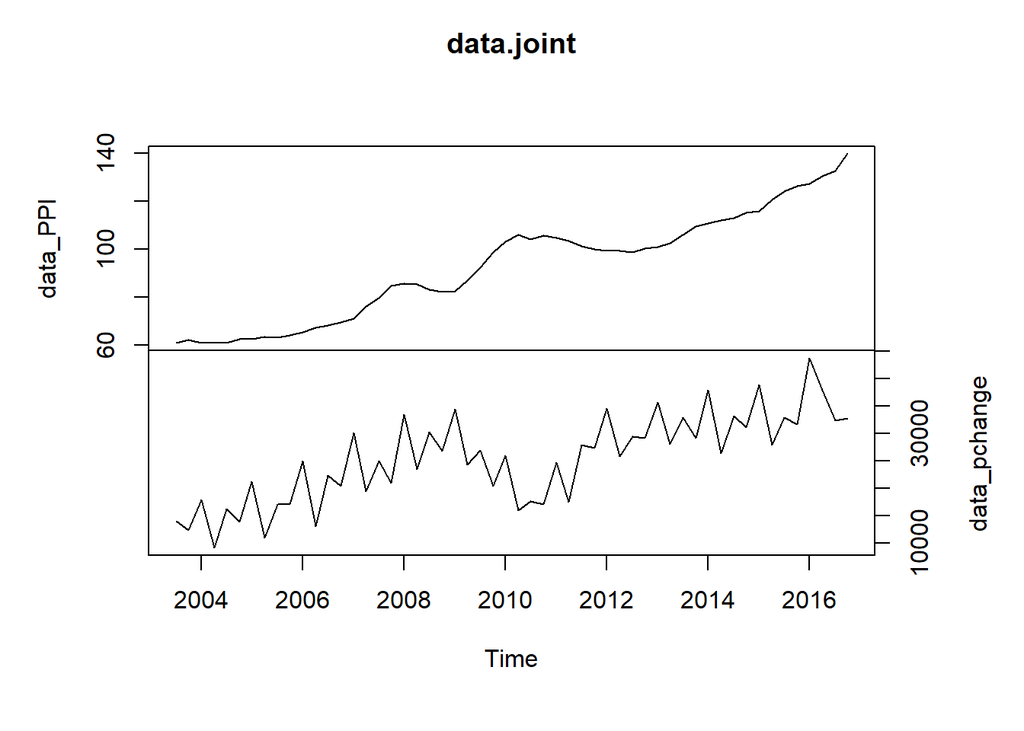

```r
plot(data.joint,yax.flip=T)
```

Time series plots of both *PPI* and *Population Change* suggest non-stationarity as there is a clear upward trend in both of these time series. Lets confirm non-stationarity in both the response and covariate TS statistically,

**Test Stationarity of Response and Covariate time series -**

Lets use ADF (Augmented Dickey-Fuller) test. The test hypothesis are,

$H_0$ : Time series is Difference non-stationary  
$H_a$ : Time series is Stationary

```r
adf.test(data.joint[,1]) # For Property Price Index (PPI)
```

```
##
##  Augmented Dickey-Fuller Test
##
## data:  data.joint[, 1]
## Dickey-Fuller = -1.3264, Lag order = 3, p-value = 0.8458
## alternative hypothesis: stationary
```

```r
adf.test(data.joint[,2]) # For Population Change
```

```
##
##  Augmented Dickey-Fuller Test
##
## data:  data.joint[, 2]
## Dickey-Fuller = -1.603, Lag order = 3, p-value = 0.7344
## alternative hypothesis: stationary
```

For both response and covariate TS, since p-value > 0.05, we fail to reject null hypothesis of non stationarity. We can conclude that the series is **non stationary** at 5% level of significance.

Thus if we see significant correlation between PPI and Population change series, it is likely due the spurious correlation due the non-stationarity of the interacting variables. We can check this by looking at the cross-correlations between PPI response and Population change covariate time series using CCF(),

**Sample CCF plot -**

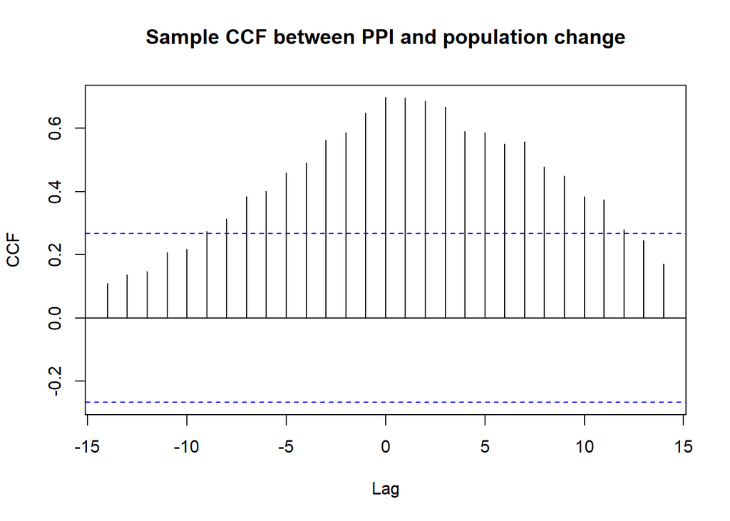

```r
ccf(as.vector(data.joint[,1]), as.vector(data.joint[,2]),ylab='CCF', main = "Sample CCF between PPI and population change")
```

Nearly all of the cross-correlations are significantly different from zero according to the 1.96/n rule. The nonstationarity in the PPI series and the Population change series is more likely the cause of the spurious correlations found between the two series.

## Prewhitening

Lets remove the spurious correlation between PPI and population change series by the process of *prewhitening* which is an approach to disentangle the linear association between PPI and Population change series from their autocorrelation.

An **approximate Prewhitening** can be achieved **by differencing** (hence, eliminating non-stationarity in these 2 series). **Further prewhitening** can be done **using the prewhiten()** which transforms one of the two series such that it is uncorrelated (white noise).

Since we have seasonal component in our response and covariate time series (not testing, rather just assuming as the data is quarterly), lets perform ordinary and seasonal differencing on both PPI and Population change series and see if the cross-correlations are removed,

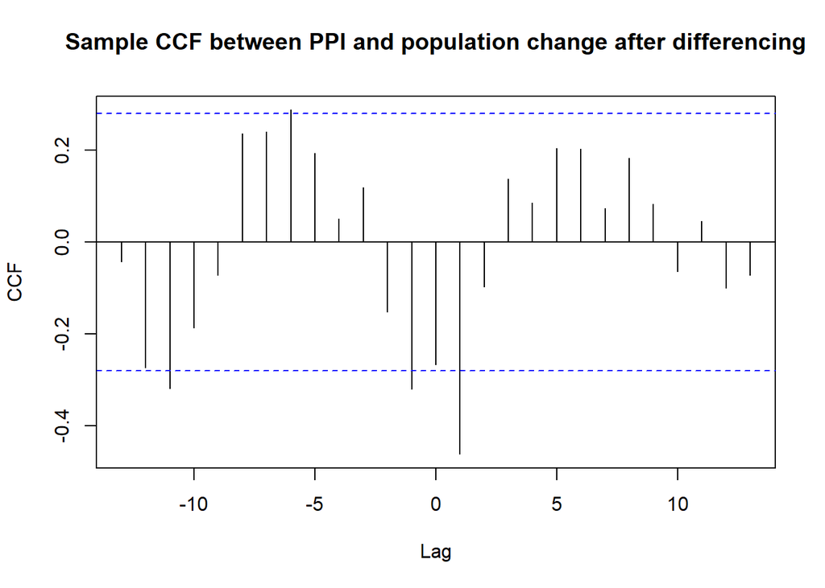

```r
# Code gist - Inner diff(TS,freq) does seasonal differencing. Outer diff(TS) does ordinary differencing
data.dif=ts.intersect(diff(diff(data_PPI,4)),diff(diff(data_pchange,4))) # Note quarterly frequency of 4 is used in seasonal differencing
ccf(as.vector(data.dif[,1]), as.vector(data.dif[,2]),ylab='CCF', main = "Sample CCF between PPI and population change after differencing")
```

From the sample CCF plot, we notice **still some cross-correlations are significant after differencing**.

Next, lets further prewhiten the differenced series using prewhiten() and check the sample CCF plot,

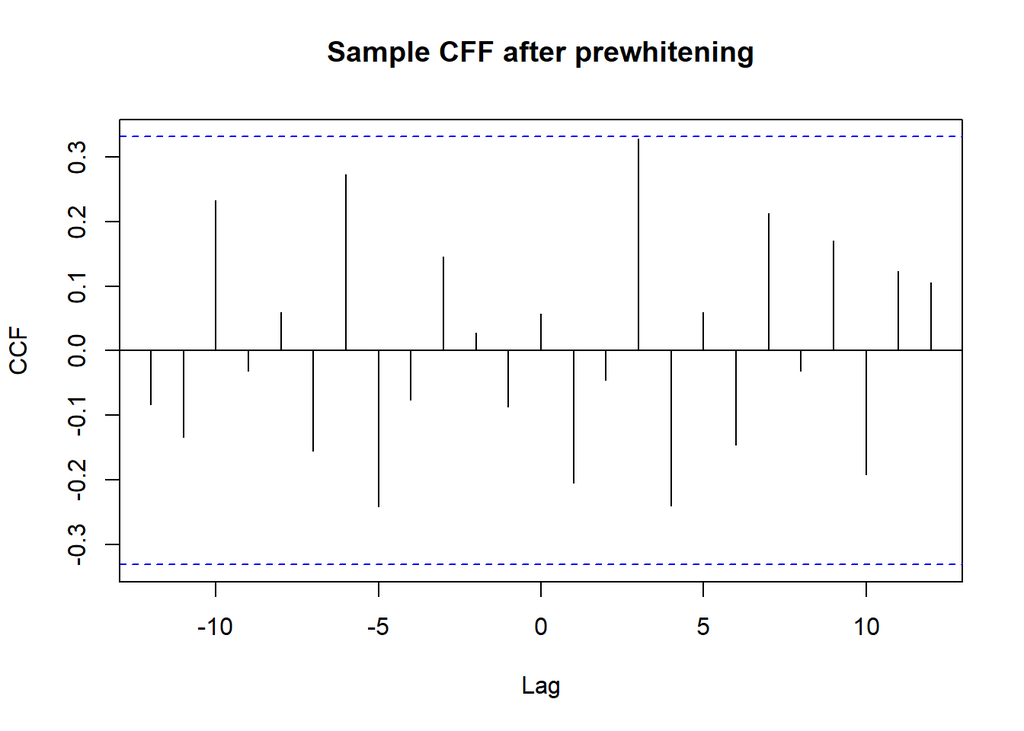

```r
prewhiten(as.vector(data.dif[,1]),as.vector(data.dif[,2]),ylab='CCF', main="Sample CFF after prewhitening") # library(TSA)
```

From the plot above, all the **cross-correlations are insignificant** according to the 1.96/n rule. Hence, spurious correlation has been eliminated from PPI and Population change series.

**Thus, it seems that Property Price Index (PPI) and Population change are in fact largely uncorrelated, and the strong cross-correlations found between the raw data series is indeed spurious.**

## Reference List

Rob Hyndman (2013) *Does the Holt-Winters algorithm for exponential smoothing in time series modelling require the normality assumption in residuals?*, Stack Exchange Website, accessed 26 September 2023. https://stats.stackexchange.com/questions/64911/does-the-holt-winters-algorithm-for-exponential-smoothing-in-time-series-modelli#:~:text=There%20is%20no%20normality%20assumption,under%20almost%20all%20residual%20distributions.